This tutorial is automatically generated from the file test/python/cell_based/tutorials/TestTensileTestTutorial.py.

```python
# Jupyter notebook specific imports
import matplotlib as mpl
import matplotlib.pyplot as plt
%matplotlib inline
```

# Introduction

In this tutorial we will demonstrate a simulated tensile test on an epithelial sheet. This test demonstrates:

- Working with vertex based off lattice populations
- Applying boundary conditions
- Working with forces

## The Test

```python
import numpy as np
import chaste
chaste.init()
import chaste.cell_based
import chaste.mesh
import chaste.visualization
```

## Test 1 - A 2d test

First, we generate a vertex mesh using a HoneycombVertexMeshGenerator.

```python
# Set up the test
chaste.cell_based.SetupNotebookTest()

generator = chaste.mesh.HoneycombVertexMeshGenerator(5, 15)
mesh = generator.GetMesh()
```

Now set up the cells, again we want to avoid proliferation.

```python
cells = chaste.cell_based.VecCellPtr()
differentiated_type = chaste.cell_based.DifferentiatedCellProliferativeType()
cell_generator = chaste.cell_based.CellsGeneratorUniformG1GenerationalCellCycleModel_2()
cell_generator.GenerateBasicRandom(cells, mesh.GetNumElements(), differentiated_type)
```

Next, create the cell population

```python
cell_population = chaste.cell_based.VertexBasedCellPopulation2(mesh, cells)
```

PyChaste can do simple 3D rendering with VTK. We set up a VtkScene so that we can see the population evovle in real time.

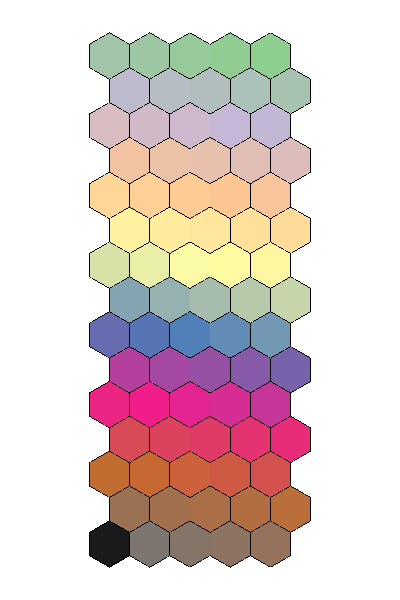

```python
scene= chaste.visualization.VtkScene2()
scene.SetCellPopulation(cell_population)
nb_manager = chaste.visualization.JupyterNotebookManager()
nb_manager.vtk_show(scene, height=600)
```

Pass the cell population into an `OffLatticeSimulation`, and set the output directory, output multiple and end time

```python
simulator = chaste.cell_based.OffLatticeSimulation2_2(cell_population)
simulator.SetOutputDirectory("Python/TestTensileTest")
simulator.SetEndTime(2.0)
simulator.SetSamplingTimestepMultiple(200)
```

Now create a force law

```python
force = chaste.cell_based.NagaiHondaForce2()
simulator.AddForce(force)
```

A NagaiHondaForce assumes that each cell has a target area. The target areas of cells are used to determine pressure forces on each vertex and eventually determine the size of each cell in the simulation. In order to assign target areas to cells and update them in each time step we add a SimpleTargetAreaModifier to the simulation, which inherits from AbstractTargetAreaModifier.

```python
growth_modifier = chaste.cell_based.SimpleTargetAreaModifier2()
simulator.AddSimulationModifier(growth_modifier)
```

For our tensile test we will fix the bottom of the sheet and subject the top to an applied displacement. We neglect fixing lateral degress of freedom for simplicity, since we are using an over-damped mechanical model.

```python
point = (0.0, 0.0)
normal = (0.0, -1.0)
bc = chaste.cell_based.AttractingPlaneBoundaryCondition2_2(cell_population, point, normal)
simulator.AddCellPopulationBoundaryCondition(bc)
point = (0.0, 13.3)
normal = (0.0, 1.0)
bc2 = chaste.cell_based.AttractingPlaneBoundaryCondition2_2(cell_population, point, normal)
simulator.AddCellPopulationBoundaryCondition(bc2)
```

We want to displace our top boundary over time. We could write a custom boundary condition class to do this. A more simple alternative is to modify the the position of the point describing our boundary plane in `bc2` as the simulation progresses. As per earlier tutorials we make a new `SimulationModifier` class to do this.

```python
class BoundaryConditionModifier(chaste.cell_based.AbstractCellBasedSimulationModifier2_2):

    """ Class for time varying boundary conditions
    """

    def __init__(self, boundary_condition):
        self.boundary_condition = boundary_condition
        self.original_location = boundary_condition.rGetPointOnPlane()
        self.velocity = 0.5 # cell lengths per time
        super(BoundaryConditionModifier, self).__init__()

    def UpdateAtEndOfTimeStep(self, cell_population):

        """ Move the boundary upwards at the specified velocity
        """

        total_time = chaste.cell_based.SimulationTime.Instance().GetTime()
        new_location = [self.original_location[0], self.original_location[1]+self.velocity*total_time]
        self.boundary_condition.SetPointOnPlane(np.array(new_location))

    def SetupSolve(self, cell_population, output_directory):

        """ Make sure the cell population is in the correct state at the start of the simulation
        """

        cell_population.Update()

    def OutputSimulationModifierParameters(self, rParamsFile):

        """ This needs to be explicitly over-ridden as the C++ method is pure virtual.
        """

        pass
bc_modifier = BoundaryConditionModifier(bc2)
simulator.AddSimulationModifier(bc_modifier)
```

Save snapshot images of the population during the simulation

```python
scene_modifier = chaste.visualization.JupyterSceneModifier2(nb_manager)
scene_modifier.SetVtkScene(scene)
scene_modifier.SetUpdateFrequency(1000)
simulator.AddSimulationModifier(scene_modifier)
```

To run the simulation, we call `Solve()`.

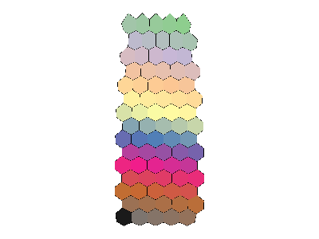

```python
scene.Start()
simulator.Solve();
```